# STAT425_FinalProject

# Part II- Unbalanced Anova :

First, we create a dataframe after excluding the invalid observations:

```r
mask = !((df$replication == 2) & (df$run_order == 2 | df$run_order == 3 |df$run_order == 5))
df_part2 = df[mask, ]
```

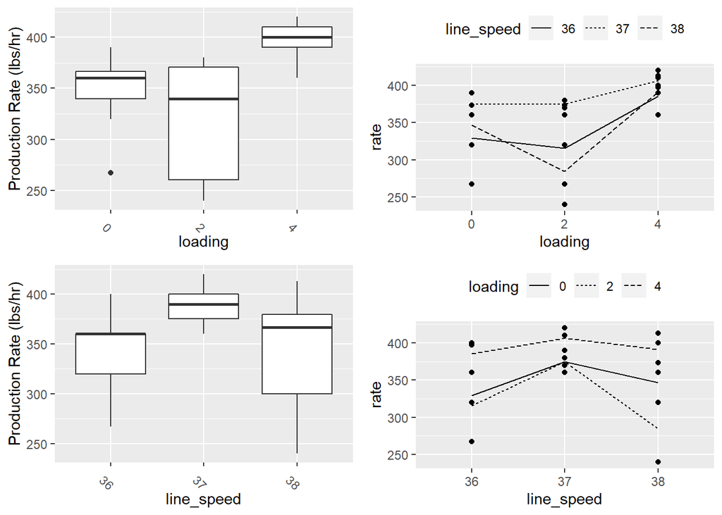

```r
p1 = ggplot(aes(x=loading, y=rate), data=df_part2) +
  geom_boxplot() +
  theme(axis.text.x = element_text(angle=-45)) +
  ylab("Production Rate (lbs/hr)")

p2 = ggplot(aes(x=line_speed, y=rate), data=df_part2) +
  geom_boxplot() +
  theme(axis.text.x = element_text(angle=-45)) +
  ylab("Production Rate (lbs/hr)")

p3 = ggplot(df_part2, aes(x=loading, y=rate)) +
  geom_point() +
  stat_summary(fun="mean", geom="line", aes(group=line_speed, linetype=line_speed))+
  theme(legend.position = "top", legend.direction = "horizontal")

p4 = ggplot(df_part2, aes(x=line_speed, y=rate)) +
  geom_point() +
  stat_summary(fun="mean", geom="line", aes(group=loading, linetype=loading))+
  theme(legend.position = "top", legend.direction = "horizontal")

multiplot(p1, p2, p3, p4, cols=2)
```

Let’s fit a two-way anova model:

```r
model2 = lm(rate^5~ line_speed*loading, data = df_part2)
summary(model2)
```

```
##
## Call:
## lm(formula = rate^5 ~ line_speed * loading, data = df_part2)
##
## Residuals:
##        Min         1Q     Median         3Q        Max
## -3.387e+12 -2.141e+12  4.272e+11  1.563e+12  4.283e+12
##
## Coefficients:
##                         Estimate Std. Error t value Pr(>|t|)
## (Intercept)            4.483e+12  1.517e+12   2.955  0.00983 **
## line_speed37           3.051e+12  2.399e+12   1.272  0.22274
## line_speed38           8.044e+11  2.399e+12   0.335  0.74201
## loading2              -8.971e+11  2.145e+12  -0.418  0.68178
## loading4               4.233e+12  2.145e+12   1.973  0.06723 .
## line_speed37:loading2  7.915e+11  3.392e+12   0.233  0.81866
## line_speed38:loading2 -1.453e+12  3.218e+12  -0.452  0.65805
## line_speed37:loading4 -5.415e+11  3.218e+12  -0.168  0.86862
## line_speed38:loading4 -8.639e+10  3.218e+12  -0.027  0.97894
## ---
## Signif. codes:  0 '***' 0.001 '**' 0.01 '*' 0.05 '.' 0.1 ' ' 1
##
## Residual standard error: 2.628e+12 on 15 degrees of freedom
## Multiple R-squared:  0.6457, Adjusted R-squared:  0.4568
## F-statistic: 3.418 on 8 and 15 DF,  p-value: 0.0193
```

Since, the model is an unbalanced anova, we need to use Type III Anova test to determine the significance. However, we should ascertain whether the residuals are normally distributed.

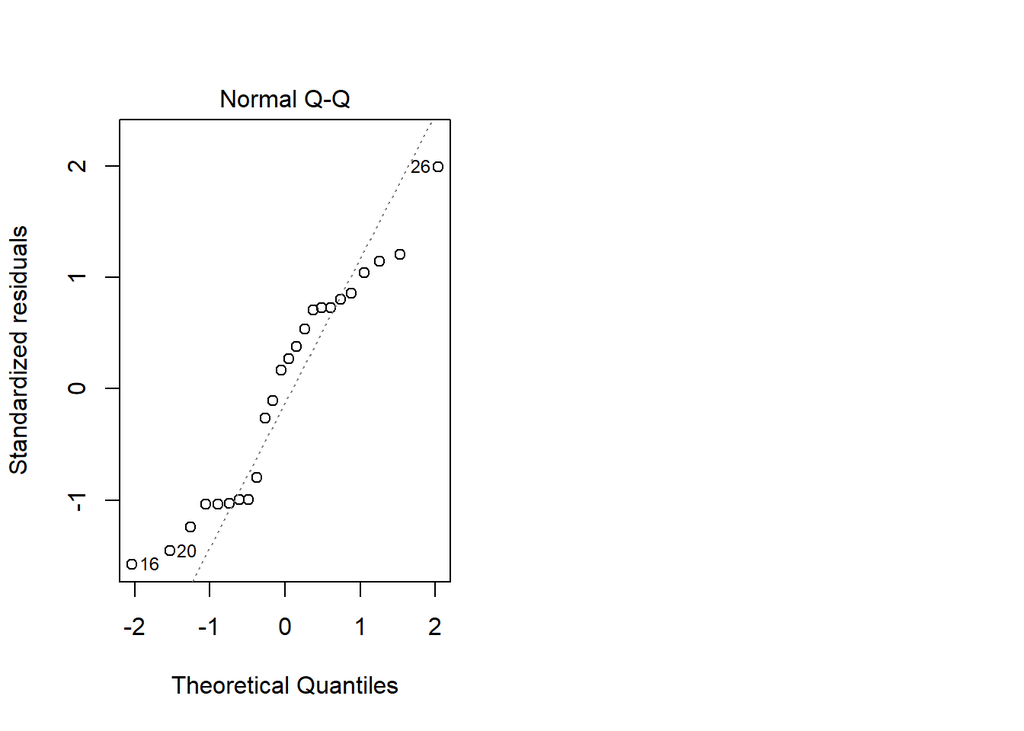

```r
par(mfrow = c(1, 2))
#Normal QQ plot of the residuals:
plot(model2, which = 2)
```

The QQ plot looks almost linear. We expect the errors to be approximately distributed. Let’s check this using the Shapiro_Wilk Test as under:

```r
shapiro.test(model2$residuals)
```

```
##
##  Shapiro-Wilk normality test
##
## data:  model2$residuals
## W = 0.93991, p-value = 0.1624
```

Since the p-value is larger than 0.05, we can’t reject the null hypothesis which assumes the errors are normally distributed. Thus, we can go on to check for the significance of the predictors through the Type III Anova as follows:

```r
library(car)
Anova(model2,type = 'III')
```

```
## Anova Table (Type III tests)
##
## Response: rate^5
##                        Sum Sq Df F value   Pr(>F)
## (Intercept)        6.0302e+25  1  8.7339 0.009827 **
## line_speed         1.1419e+25  2  0.8269 0.456387
## loading            4.5035e+25  2  3.2613 0.066675 .
## line_speed:loading 5.4919e+24  4  0.1989 0.935083
## Residuals          1.0357e+26 15
## ---
## Signif. codes:  0 '***' 0.001 '**' 0.01 '*' 0.05 '.' 0.1 ' ' 1
```

```r
model2.additive = lm(rate^5 ~ line_speed+loading, data = df_part2)
summary(model2.additive)
```

```
##
## Call:
## lm(formula = rate^5 ~ line_speed + loading, data = df_part2)
##
## Residuals:
##        Min         1Q     Median         3Q        Max
## -3.286e+12 -2.231e+12  8.026e+11  1.409e+12  3.524e+12
##
## Coefficients:
##                Estimate Std. Error t value Pr(>|t|)
## (Intercept)   4.643e+12  1.075e+12   4.319  0.00037 ***
## line_speed37  3.048e+12  1.211e+12   2.517  0.02098 *
## line_speed38  2.471e+11  1.168e+12   0.212  0.83468
## loading2     -1.194e+12  1.243e+12  -0.961  0.34881
## loading4      4.050e+12  1.211e+12   3.344  0.00341 **
## ---
## Signif. codes:  0 '***' 0.001 '**' 0.01 '*' 0.05 '.' 0.1 ' ' 1
##
## Residual standard error: 2.396e+12 on 19 degrees of freedom
## Multiple R-squared:  0.6269, Adjusted R-squared:  0.5484
## F-statistic: 7.983 on 4 and 19 DF,  p-value: 0.0005945
```

Let’s test each variable individually to check whether they are statistically significant or not.

**Loading Percentage**

```r
model2.line_speed<-lm(rate^5 ~ line_speed, data = df_part2)
anova(model2.line_speed,model2.additive)
```

```
## Analysis of Variance Table
##
## Model 1: rate^5 ~ line_speed
## Model 2: rate^5 ~ line_speed + loading
##   Res.Df        RSS Df Sum of Sq      F    Pr(>F)
## 1     21 2.3716e+26
## 2     19 1.0906e+26  2 1.281e+26 11.159 0.0006235 ***
## ---
## Signif. codes:  0 '***' 0.001 '**' 0.01 '*' 0.05 '.' 0.1 ' ' 1
```

The above anova output tests the below hypotheses :

[
$$\begin{cases}
&H_0: Y_{ijk} = \mu + \alpha_i +\epsilon_{ijk}\\
&H_{\alpha}: Y_{ijk} = \mu + \alpha_i +\beta_j +\epsilon_{ijk}
\end{cases}$$

]

Where

- $\alpha_i$= Effect of line speed (m/mm) i on production rate of bubble wrap where i =1,2,3
- $\beta_j$= Effect of loading percentage j production rate of bubble wrap where j=1,2,3

Since p-value is less than 5%, we can reject the null hypothesis and conclude that the full additive model is adequate.

**Linespeed**

```r
model2.loading<-lm(rate^5 ~ loading, data = df_part2)
anova(model2.loading,model2.additive)
```

```
## Analysis of Variance Table
##
## Model 1: rate^5 ~ loading
## Model 2: rate^5 ~ line_speed + loading
##   Res.Df        RSS Df  Sum of Sq      F  Pr(>F)
## 1     21 1.5169e+26
## 2     19 1.0906e+26  2 4.2628e+25 3.7133 0.04353 *
## ---
## Signif. codes:  0 '***' 0.001 '**' 0.01 '*' 0.05 '.' 0.1 ' ' 1
```

```r
Anova(model2.additive, type = 'III')
```

```
## Anova Table (Type III tests)
##
## Response: rate^5
##                 Sum Sq Df F value    Pr(>F)
## (Intercept) 1.0707e+26  1 18.6534 0.0003701 ***
## line_speed  4.2628e+25  2  3.7133 0.0435287 *
## loading     1.2810e+26  2 11.1589 0.0006235 ***
## Residuals   1.0906e+26 19
## ---
## Signif. codes:  0 '***' 0.001 '**' 0.01 '*' 0.05 '.' 0.1 ' ' 1
```

From the Type III Anova, we can see that `loading` and `line_speed` both are significant at 5% significance level.

Thus, our final model is:
$$Y_{jk} = \mu + \alpha_i+\beta_j + \epsilon_{jk}$$
where,
* $Y_{jk}$ = Production Rate in lbs/hr
* $\mu$ = mean production rate of bubble wrap across all experimental settings (grand mean)
* $\beta_j$= Effect of loading percentage j production rate of bubble wrap where j=1,2,3
The error terms satisfy the assumption $\epsilon_{jk}$ ~ $\mathcal{N}(0,\sigma^2)$.

With constraint:  
$\beta_0=0$

### Model Diagnostics:

**Outliers:**

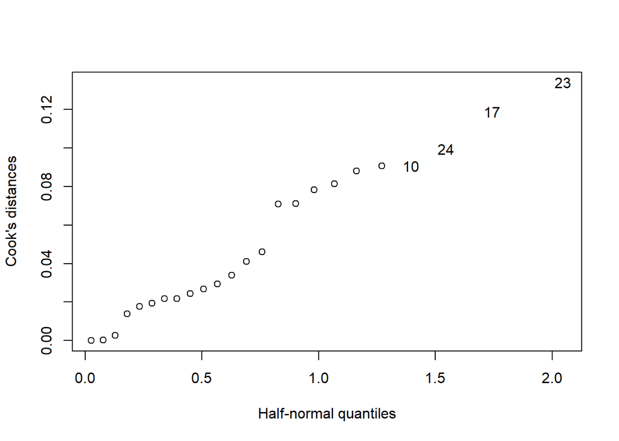

```r
cook = cooks.distance(model2.additive)
halfnorm(cook, 4, labs=as.character(1:length(cook)), ylab="Cook's distances")
```

Since all the Cook’s distances are less that 1, we can conclude there are no outliers.

**Normality**

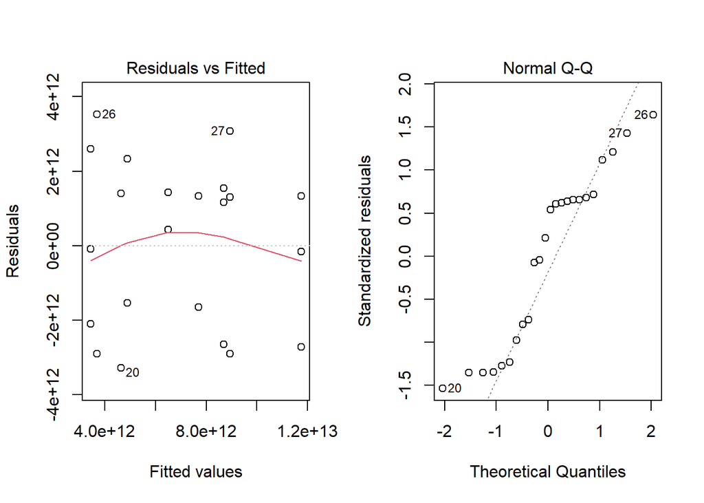

```r
par(mfrow= c(1, 2))
plot(model2.additive, which = 1)
plot(model2.additive, which = 2)
```

```r
shapiro.test(model2.additive$residuals)
```

```
##
##  Shapiro-Wilk normality test
##
## data:  model2.additive$residuals
## W = 0.9016, p-value = 0.02328
```

Since the p-value is less than 5% , we have to reject the null and conclude that the residuals are not normal. We need to do a permutation test to check for statistical significance of the factors individually. Our null hypothesis is that the factors line_speed and loading are not significant.

**Permutation Test for Linespeed**

```r
set.seed(100)
n.iter = 2000
fstats = numeric(n.iter)
for (i in 1:n.iter){
  df.temp = df_part2
  df.temp[, 'line_speed'] = c(df.temp[sample(9), 'line_speed'], df.temp[sample(c(10:15)), 'line_speed'], df.temp[sample(c(16:24)), 'line_speed']) # Shuffling the values in line_speed but only within the same trial and not across trials, otherwise we may have no value for a particular line_speed in a single trial
  reg = lm(rate^5 ~line_speed + loading, data = df.temp)
  fstats[i] = summary(reg)$fstat[1]
}
p.value = length(fstats[fstats>summary(model2.additive)$fstat[1]])/n.iter
p.value
```

```
## [1] 0.0565
```

**Permutation Test for Loading**

```r
set.seed(100)
n.iter = 2000
fstats = numeric(n.iter)
for (i in 1:n.iter){
  df.temp = df_part2
  df.temp[, 'loading'] = c(df.temp[sample(9), 'loading'], df.temp[sample(c(10:15)), 'loading'], df.temp[sample(c(16:24)), 'loading'])
  reg = lm(rate^5 ~loading + line_speed, data = df.temp)
  fstats[i] = summary(reg)$fstat[1]
}
p.value = length(fstats[fstats>summary(model2.additive)$fstat[1]])/n.iter
p.value
```

```
## [1] 0.0015
```

**Since the p-value for `loading` is less than 5%, but for `line_speed` is greater than 0.05, we can conclude that only `loading` is statistically significant. Even if we fit the model with both the variables, we expect the CI for line_speed to be containing 0. Let’s check that.**

**Levene’s Test for constancy of error variance:**

```r
df_part2$res.model2 = summary(model2.additive)$residuals

summary(lm(abs(res.model2)~loading+line_speed, data = df_part2))
```

```
##
## Call:
## lm(formula = abs(res.model2) ~ loading + line_speed, data = df_part2)
##
## Residuals:
##        Min         1Q     Median         3Q        Max
## -1.749e+12 -4.376e+11  7.793e+10  4.161e+11  1.507e+12
##
## Coefficients:
##                Estimate Std. Error t value Pr(>|t|)
## (Intercept)   1.779e+12  4.086e+11   4.354 0.000342 ***
## loading2      6.344e+10  4.726e+11   0.134 0.894630
## loading4      1.133e+10  4.604e+11   0.025 0.980617
## line_speed37 -5.105e+11  4.604e+11  -1.109 0.281280
## line_speed38  7.498e+11  4.438e+11   1.690 0.107462
## ---
## Signif. codes:  0 '***' 0.001 '**' 0.01 '*' 0.05 '.' 0.1 ' ' 1
##
## Residual standard error: 9.106e+11 on 19 degrees of freedom
## Multiple R-squared:  0.2806, Adjusted R-squared:  0.1291
## F-statistic: 1.852 on 4 and 19 DF,  p-value: 0.1605
```

Since the p-value = 0.1605 is well greater than 1%, we can’t reject the null hypothesis that the errors have constant variance.

Thus, our model is robust with respect to the model assumptions. Let’s find out the C.I. for the factors:

**Loading**

```r
TukeyHSD(aov(rate^5 ~ loading+line_speed, data=df_part2), "loading")
```

```
##   Tukey multiple comparisons of means
##     95% family-wise confidence level
##
## Fit: aov(formula = rate^5 ~ loading + line_speed, data = df_part2)
##
## $loading
##              diff           lwr          upr     p adj
## 2-0 -1.281273e+12 -4.431303e+12 1.868758e+12 0.5655894
## 4-0  4.207018e+12  1.139742e+12 7.274294e+12 0.0066843
## 4-2  5.488291e+12  2.530814e+12 8.445767e+12 0.0004241
```

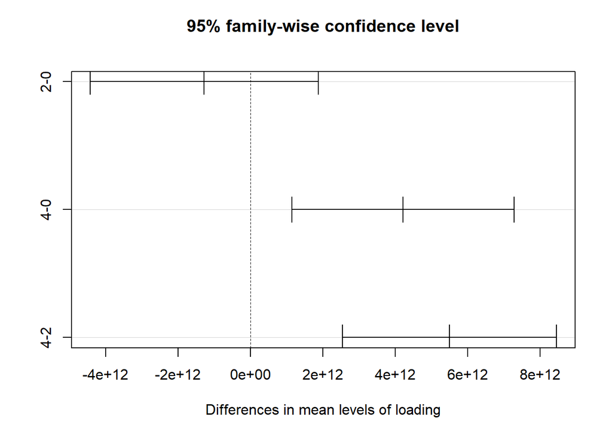

```r
myCIs = TukeyHSD(aov(rate^5 ~ loading +line_speed, data=df_part2), "loading")

plot(myCIs)
```

From the Confidence Intervals, we can observed that 4% loading has significantly better production rate than 2% and 0%. So `Loading of Additives`=4% is the optimum loading percentage for ensuring the highest production rate.

**Line Speed**

```r
TukeyHSD(aov(rate^5 ~ loading+line_speed, data=df_part2), "line_speed")
```

```
##   Tukey multiple comparisons of means
##     95% family-wise confidence level
##
## Fit: aov(formula = rate^5 ~ loading + line_speed, data = df_part2)
##
## $line_speed
##                diff           lwr          upr     p adj
## 37-36  3.029345e+12 -3.793140e+10 6.096621e+12 0.0532477
## 38-36  2.441367e+11 -2.713340e+12 3.201614e+12 0.9760773
## 38-37 -2.785208e+12 -5.935238e+12 3.648226e+11 0.0888049
```

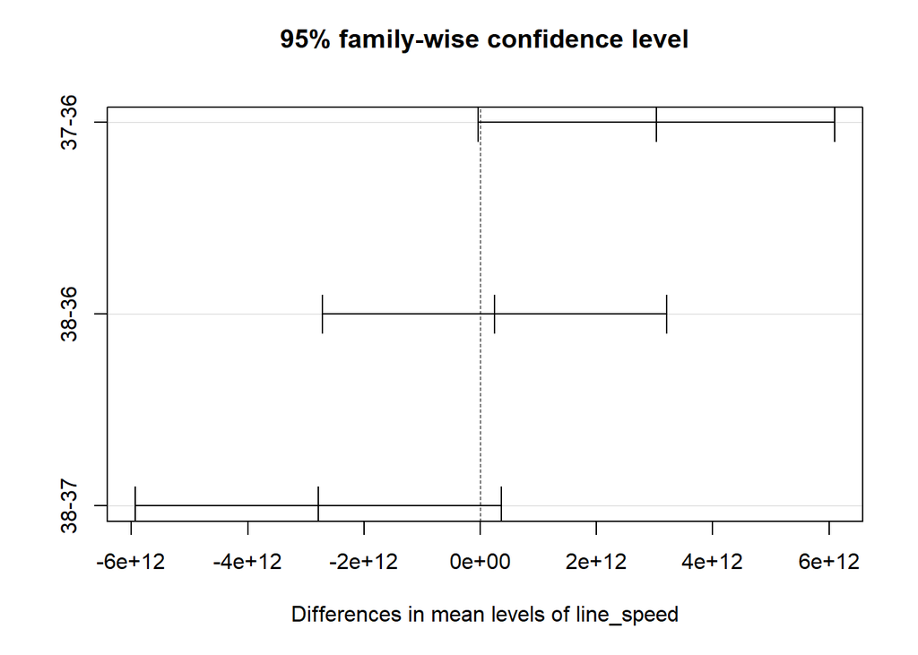

```r
myCIs = TukeyHSD(aov(rate^5 ~ loading+line_speed, data=df_part2), "line_speed")

plot(myCIs)
```

We can see from the plots above that since all 3 line speeds have 0 in their confidence intervals, with `line_speed` = 37, though showing a better point estimate than `line_speed` = 36 and `line_speed` = 38, has 0 just falling inside the CI. This was expected since the p-value for `line_speed` was just greater than 0.05. Thus, to conclude, none of the line speeds are significantly different from each other as far as their impact on the production rate is concerned. So, for the unbalanced ANOVA problem, we won’t be utilizing `line_speed` for maximizing production rate.

## Conclusion Part II

In case of unbalanced ANOVA, we removed a few datapoints before performing our analysis.The optimal conditions for maximizing production rate comes out to be a loading percentage of 4% . The different line speeds to operate the production line turns out to be statistically similar to each other and therefore any line speed can be chosen under 4% loading percentage.